# Imagenes1Angel

Como en el primer ejemplo, añadimos una línea horizontal, con la diferencia que nosotros añadiremos grosor a la línea.

```python
from PIL import Image

def line_h_gruesa(img, color, grosor):
    """
    Draw an horizontal line in the middle of the image 'img' of color 'color'
    @type img: PIL.Image
    @type color: either a number between 0..255 (gray) or a 3-tuple (r,g,b)
    """
    width, height = img.size
    for x in range(width):
        for g in range(-grosor//2,grosor//2,1):
            img.putpixel((x,height//2+g),color)
```

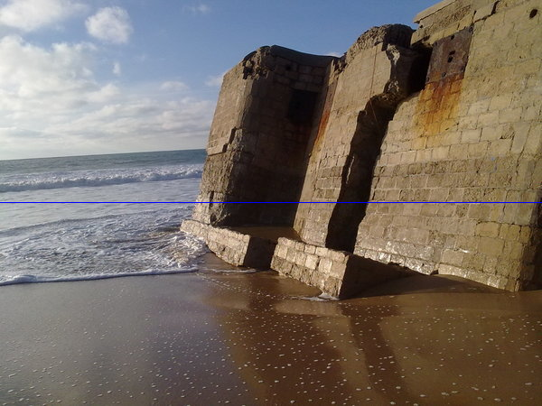

```python
i = Image.open('beach.png')
line_h_gruesa(i,(0,0,255),1)
display(i)
```

Probemos con distintos grosores: 5, 30 o incluso 100!

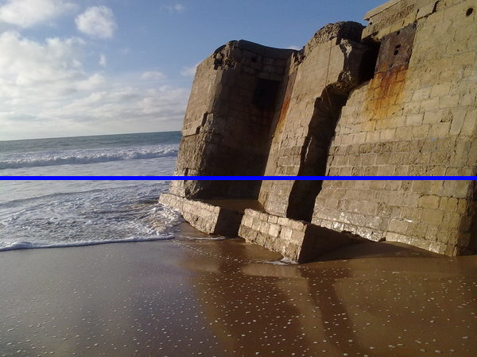

```python
line_h_gruesa(i,(0,0,255),5)
display(i)
```

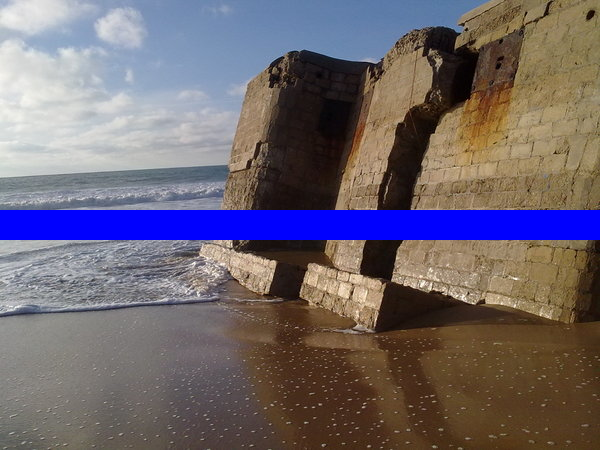

```python
line_h_gruesa(i,(0,0,255),30)
display(i)
```

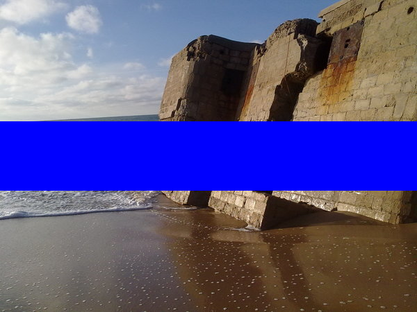

```python
line_h_gruesa(i,(0,0,255),100)
display(i)
```

Dejemos de lado el grosor, pasemos a hacer una cuadrícula encima de la imagen:

```python
def  cuadricula(img,color,numverticales,numhorizontales):
    width, height = img.size
    v = width // numverticales
    h = height // numhorizontales
    for y in range(height):
        for x in range(v,numverticales*v,v):
            img.putpixel((x,y),color)
    for x in range(width):
        for y in range(h,numhorizontales*h,h):
            img.putpixel((x,y),color)
```

[figure not shown]

```python
img = Image.open('beach.png')
cuadricula(img,(0,0,0),20,30)
display(img)
```

```python
cuadricula(img,(0,0,0),0,0)
display(img)
```

```
---------------------------------------------------------------------------
ZeroDivisionError                         Traceback (most recent call last)
<ipython-input-16-8b64b5361df4> in <module>
----> 1 cuadricula(img,(0,0,0),0,0)
      2 display(img)

<ipython-input-10-597cd7fd4b6f> in cuadricula(img, color, numverticales, numhorizontales)
      1 def  cuadricula(img,color,numverticales,numhorizontales):
      2     width, height = img.size
----> 3     v = width // numverticales
      4     h = height // numhorizontales
      5     for y in range(height):

ZeroDivisionError: integer division or modulo by zero
```

Mucho cuidado, porque tal y como la he definido haremos mínimo una linea en cada eje!! De lo contrario dividiríamos entre 0, tampoco tiene sentido hacer un número negativo de líneas. Recordar también que ahora 'img' está asociada a la imagen con cuadrícula.

[figure not shown]

```python
img = Image.open('beach.png')
cuadricula(img,(0,0,0),100,50)
display(img)
```

Siguiente tipo de ejercicios: incluimos líneas diagonales.

```python
def UKflag(img,color):
    width, height = img.size
    tol = 10**(-10)
    if width >= height:
        for x in range(width):
            img.putpixel((x,height//2),color)
            if abs( (height/width)*x - (height*x)//width ) < tol:
                img.putpixel((x,(x*height)//width),color)
                img.putpixel((x,height-(x*height)//width-1),color)
    else:
        for x in range (height):
            if abs( (width/height)*x - (width*x)//height ) < tol:
                img.putpixel(((width*x)//height,height-x-1),color)
                img.putpixel(((width*x)//height,x),color)
        for x in range(width):
            img.putpixel((x,height//2),color)
    display(img)
```

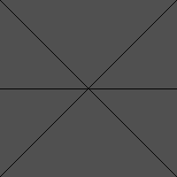

```python
gris = Image.new("L", (200,200), 80)
UKflag(gris,0)
```

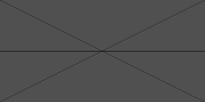

```python
gris = Image.new("L", (400,200), 80)
UKflag(gris,0)
```

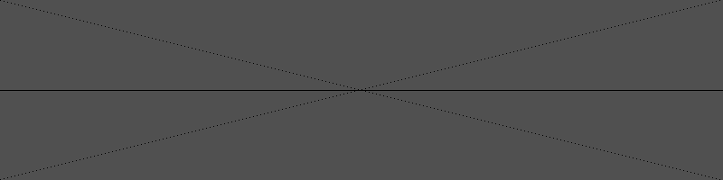

```python
gris = Image.new("L", (800,200), 80)
UKflag(gris,0)
```

Con este código solo dibujamos las duplas de coordenadas exactamente enteras reales de las diagonales. Da la sensación de que faltan puntos. Como no hay manera de agregar color a la 'mitad de un pixel', la opción más sencilla es pintar todos los puntos a la altura del anterior 'entero' hasta bajar en 'una unidad entera' la altura. Espero haberme explicado. En nuestro código basta con eliminar la condición de que las coordenadas sean 'enteras salvo una tolerancia'.

```python
def UKflag_bien(img,color):
    width, height = img.size
    if width >= height:
        for x in range(width):
            img.putpixel((x,height//2),color)
            img.putpixel((x,(x*height)//width),color)
            img.putpixel((x,height-(x*height)//width-1),color)
    else:
        for x in range (height):
            img.putpixel(((width*x)//height,height-x-1),color)
            img.putpixel(((width*x)//height,x),color)
        for x in range(width):
            img.putpixel((x,height//2),color)
    display(img)
```

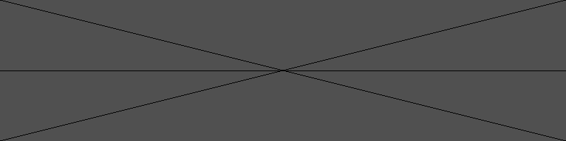

```python
gris = Image.new("L", (800,200), 80)
UKflag_bien(gris,0)
```

¡Ahora sí! Por cierto, creo que el nombre 'UKflag' es bastante descriptivo (y acertado) para este programa. Veamos que para imágenes a color también va perfecto y que el caso en el que la altura es mayor que la anchura es completamente análogo

```python
azul = Image.new("RGB",(100,200),(0,0,150))
UKflag_bien(azul,(255,0,0))
```

[output not shown]

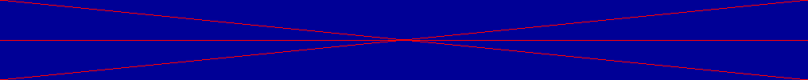

```python
azul = Image.new("RGB",(1000,100),(0,0,150))
UKflag_bien(azul,(255,0,0))
```

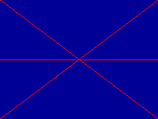

```python
azul = Image.new("RGB",(200,150),(0,0,150))
UKflag_bien(azul,(255,0,0))
```

Me siento tentado a añadir aquello del grosor con lo que empecé, hacer que las últimas líneas del 'grosor' sean blancas y terminar de rematar la broma de 'UKflag' pero creo que he tenido suficiente por hoy.

```python
import math

def sinusoide(img,color):
    width, height = img.size
    for x in range(width):
        y = int(height*math.sin(x/20))
        img.putpixel((x,y),color)
    display(img)
```

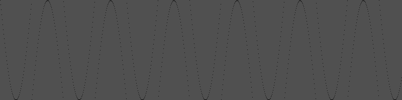

```python
gris = Image.new("L", (800,200), 80)
sinusoide(gris,0)
```

Oops, creo que esto no era lo que andaba buscando, queda bonito así que lo dejaré. Vamos a intentar arreglarlo

Pues no he sido capaz, pero si he podido meterle el número de 'vueltas completas al seno' que queremos hacer. Les he llamado 'loops'.

```python
def sinusoide(img,color,loops):
    width, height = img.size
    for x in range(width):
        y = int(height*math.sin((3.1416/2)*x*loops/height))
        img.putpixel((x,y),color)
    display(img)
```

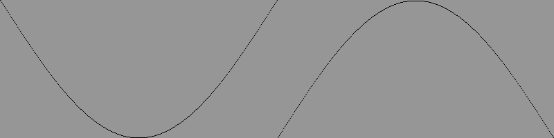

```python
gris = Image.new("L", (800,200), 150)
sinusoide(gris,0,1)
```

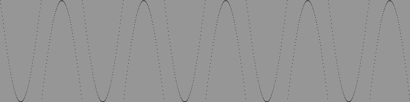

```python
gris = Image.new("L", (800,200), 150)
sinusoide(gris,0,5)
```

Si en lugar de dividir pi entre 2 hubiera dejado pi, 'loops' haría referencia al número de ondas que queríamos hacer (i.e. el seno de 0 a pi).

Si ponía 'math.pi' me daba error aunque en teoría debería ser el valor de pi. Al final he optado por poner '3.1416' a lo cutre.

Tampoco entiendo del todo por qué no me dibuja el seno, cada vez que aparece trigonometría en alguna asignatura acabo agachando la cabeza y esperando que pase el mal tiempo.